# NYPD Shooting

Anonymous Learner

2025-01-24

# NYPD Shooting

This dataset looks at historic NYPD shooting records. Make sure to install and run the tidyverse package.

## Purpose

The purpose of this data analysis is to look at historic shooting data in NYPD, specifically looking at NY boroughs and demographics of the perpetrator of the shootings.

```r
url<-"https://data.cityofnewyork.us/api/views/833y-fsy8/rows.csv?accessType=DOWNLOAD"
NYPD_shooting<-read_csv(url,show_col_types = FALSE)
```

## Tidying the Data

```r
#Change OCCUR_DATE from character to date,Change race, sex, and age to factor, and remove longitude/latitude columns as those will not be used in this analysis.
NYPD<- NYPD_shooting %>% mutate(OCCUR_DATE= mdy(OCCUR_DATE)) %>% mutate(PERP_RACE= as.factor(PERP_RACE)) %>% mutate(PERP_SEX=as.factor(PERP_SEX)) %>% mutate(PERP_AGE_GROUP=as.factor(PERP_AGE_GROUP)) %>% select (-c(X_COORD_CD, Y_COORD_CD, Latitude, Longitude, Lon_Lat,))
```

There are some missing values for Location of occurrence, age, sex, and race, but I do not want to remove these incidences. I will include the “Not reported” category as needed throughout my analysis and include “when location was known,” or similar to represent missing data.

```
##   INCIDENT_KEY         OCCUR_DATE          OCCUR_TIME           BORO
##  Min.   :  9953245   Min.   :2006-01-01   Length:28562      Length:28562
##  1st Qu.: 65439914   1st Qu.:2009-09-04   Class1:hms        Class :character
##  Median : 92711254   Median :2013-09-20   Class2:difftime   Mode  :character
##  Mean   :127405824   Mean   :2014-06-07   Mode  :numeric
##  3rd Qu.:203131993   3rd Qu.:2019-09-29
##  Max.   :279758069   Max.   :2023-12-29
##
##  LOC_OF_OCCUR_DESC     PRECINCT     JURISDICTION_CODE LOC_CLASSFCTN_DESC
##  Length:28562       Min.   :  1.0   Min.   :0.0000    Length:28562
##  Class :character   1st Qu.: 44.0   1st Qu.:0.0000    Class :character
##  Mode  :character   Median : 67.0   Median :0.0000    Mode  :character
##                     Mean   : 65.5   Mean   :0.3219
##                     3rd Qu.: 81.0   3rd Qu.:0.0000
##                     Max.   :123.0   Max.   :2.0000
##                                     NA's   :2
##  LOCATION_DESC      STATISTICAL_MURDER_FLAG PERP_AGE_GROUP   PERP_SEX
##  Length:28562       Mode :logical           18-24  :6438   (null): 1141
##  Class :character   FALSE:23036             25-44  :6041   F     :  444
##  Mode  :character   TRUE :5526              UNKNOWN:3148   M     :16168
##                                             <18    :1682   U     : 1499
##                                             (null) :1141   NA's  : 9310
##                                             (Other): 768
##                                             NA's   :9344
##           PERP_RACE     VIC_AGE_GROUP        VIC_SEX
##  BLACK         :11903   Length:28562       Length:28562
##  WHITE HISPANIC: 2510   Class :character   Class :character
##  UNKNOWN       : 1837   Mode  :character   Mode  :character
##  BLACK HISPANIC: 1392
##  (null)        : 1141
##  (Other)       :  469
##  NA's          : 9310
##    VIC_RACE
##  Length:28562
##  Class :character
##  Mode  :character
##
##
##
##
```

## Analyzing the Data

First, I want to calculate the totals by each NY borough by date.

```r
#Number of Incidents by Boro by Date
By_Boro<- NYPD_shooting %>%
  mutate(OCCUR_DATE= mdy(OCCUR_DATE)) %>%
  group_by(BORO,OCCUR_DATE) %>%
  summarize(SHOOTINGS=n(), .groups="drop")

head (By_Boro)
```

```
## # A tibble: 6 × 3
##   BORO  OCCUR_DATE SHOOTINGS
##   <chr> <date>         <int>
## 1 BRONX 2006-01-01         2
## 2 BRONX 2006-01-04         1
## 3 BRONX 2006-01-05         2
## 4 BRONX 2006-01-06         3
## 5 BRONX 2006-01-09         4
## 6 BRONX 2006-01-10         1
```

Next, I will sum number of incidences in each boro by year from 2006-2023.

```r
Totals_by_Boro<-By_Boro %>%
  mutate(YEAR= year(OCCUR_DATE)) %>%
  group_by(BORO,YEAR) %>%
  summarize(TOTAL_SHOOTINGS=sum(SHOOTINGS, na.rm=TRUE)) %>%
  #select(BORO, OCCUR_DATE,TOTAL_SHOOTINGS) %>%
  ungroup()
head(Totals_by_Boro)
```

```
## # A tibble: 6 × 3
##   BORO   YEAR TOTAL_SHOOTINGS
##   <chr> <dbl>           <int>
## 1 BRONX  2006             568
## 2 BRONX  2007             533
## 3 BRONX  2008             520
## 4 BRONX  2009             529
## 5 BRONX  2010             525
## 6 BRONX  2011             571
```

## Visualizing the Data

Below is a graph of shooting incidences over time by each borough.

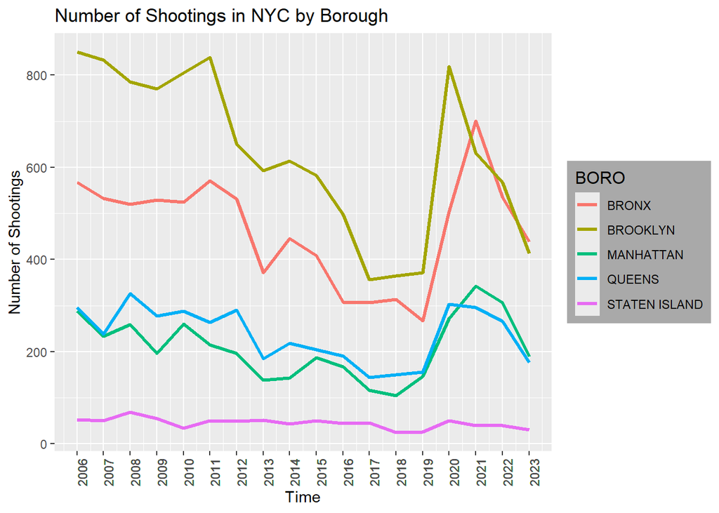

```r
Totals_by_Boro %>%
  ggplot(aes(x=YEAR, y=TOTAL_SHOOTINGS, group=BORO, color=BORO))+
  geom_line(linewidth=1.2)+
  theme(axis.text.x=element_text(angle=90), legend.background=element_rect(fill="darkgray"),
        legend.title=element_text(size=12))+
  scale_x_continuous(breaks=Totals_by_Boro$YEAR)+
  labs(title="Number of Shootings in NYC by Borough",y="Number of Shootings", x="Time")
```

## Modeling

Polynomial Regression

```r
Boro_MOD<- Totals_by_Boro %>% mutate(BORO= as.factor(BORO))
mod<- lm(TOTAL_SHOOTINGS~poly(YEAR,2)+BORO, data=Boro_MOD)
summary(mod)
```

```
##
## Call:
## lm(formula = TOTAL_SHOOTINGS ~ poly(YEAR, 2) + BORO, data = Boro_MOD)
##
## Residuals:
##      Min       1Q   Median       3Q      Max
## -227.246  -42.978    1.513   38.555  259.731
##
## Coefficients:
##                   Estimate Std. Error t value Pr(>|t|)
## (Intercept)         465.33      21.34  21.802  < 2e-16 ***
## poly(YEAR, 2)1     -343.20      90.55  -3.790 0.000284 ***
## poly(YEAR, 2)2      315.20      90.55   3.481 0.000800 ***
## BOROBROOKLYN        165.00      30.18   5.466 4.72e-07 ***
## BOROMANHATTAN      -256.33      30.18  -8.492 6.77e-13 ***
## BOROQUEENS         -228.06      30.18  -7.555 4.96e-11 ***
## BOROSTATEN ISLAND  -420.50      30.18 -13.931  < 2e-16 ***
## ---
## Signif. codes:  0 '***' 0.001 '**' 0.01 '*' 0.05 '.' 0.1 ' ' 1
##
## Residual standard error: 90.55 on 83 degrees of freedom
## Multiple R-squared:  0.8558, Adjusted R-squared:  0.8453
## F-statistic: 82.08 on 6 and 83 DF,  p-value: < 2.2e-16
```

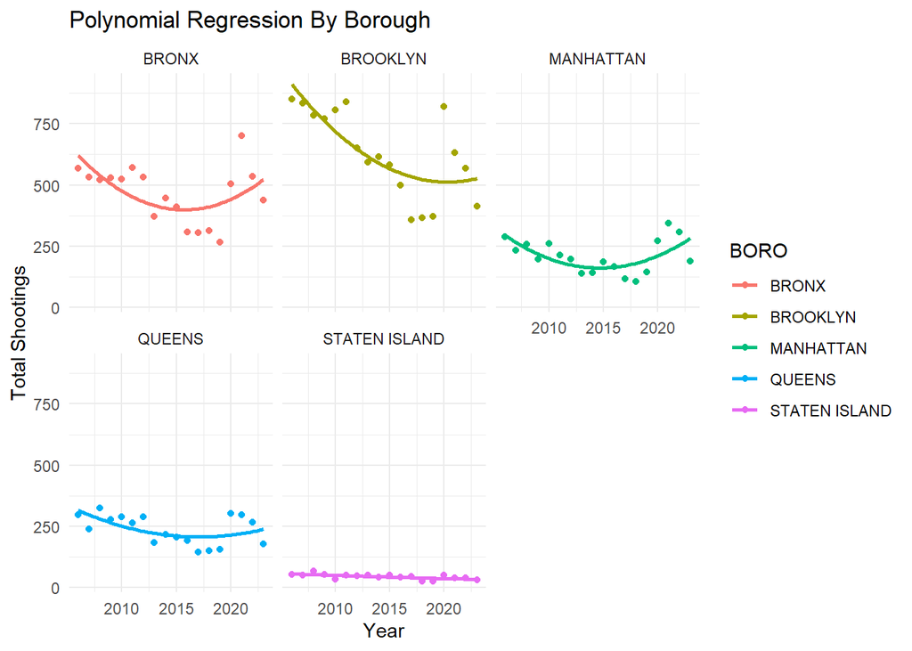

```r
ggplot(Boro_MOD, aes(x=YEAR, y=TOTAL_SHOOTINGS, color=BORO))+
  geom_point() +
  stat_smooth(method="lm", formula=y ~poly(x,2), se=FALSE)+
  facet_wrap(~BORO)+
  labs(title="Polynomial Regression By Borough",x="Year",y="Total Shootings")+
  theme_minimal()
```

## Further Analysis

We can see that Brooklyn has the highest amounts of shooting incidents. Let’s look at that boro more closely.

```r
Brooklyn<- NYPD_shooting %>%
  filter(BORO== "BROOKLYN") %>%
  mutate(OCCUR_DATE= mdy(OCCUR_DATE)) %>%
  group_by(PERP_SEX,PERP_RACE, PERP_AGE_GROUP,OCCUR_DATE) %>%
  mutate(OCCUR_DATE= year(OCCUR_DATE))%>%
  mutate(PERP_RACE= as.factor(PERP_RACE)) %>% mutate(PERP_SEX=as.factor(PERP_SEX)) %>% mutate(PERP_AGE_GROUP=as.factor(PERP_AGE_GROUP)) %>%
  #summarize(INCIDENT_KEY= n_distinct(INCIDENT_KEY)) %>%
  select(PERP_SEX,PERP_RACE, PERP_AGE_GROUP,OCCUR_DATE) %>%
  ungroup()
head(Brooklyn)
```

```
## # A tibble: 6 × 4
##   PERP_SEX PERP_RACE      PERP_AGE_GROUP OCCUR_DATE
##   <fct>    <fct>          <fct>               <dbl>
## 1 M        WHITE HISPANIC 25-44                2018
## 2 U        UNKNOWN        UNKNOWN              2006
## 3 <NA>     <NA>           <NA>                 2011
## 4 <NA>     <NA>           <NA>                 2012
## 5 M        BLACK          25-44                2015
## 6 M        BLACK          18-24                2016
```

```r
Brooklyn<- NYPD_shooting %>%
  filter(BORO== "BROOKLYN")
  #mutate(OCCUR_DATE= mdy(OCCUR_DATE)) %>%
  #mutate(YEAR= year(OCCUR_DATE))

Brooklyn_Summary<-Brooklyn %>%
  group_by(PERP_SEX,PERP_RACE, PERP_AGE_GROUP) %>%
  summarize(SHOOTINGS=n(), .groups="drop")
```

Now that I have all of Brooklyn’s shooting incidents by year and perpetrator demographics, I want to look at who is perpetrating shootings in Brooklyn.